# Простые сети в GNS3. Анализ трафика

Лабораторная работа №5

Суннатилло Махмудов

Российский университет дружбы народов, Москва, Россия

29 октября 2025

# Цели и задачи работы

## Цель лабораторной работы

Построение простейших моделей сети на базе коммутатора и маршрутизаторов **FRR** и **VyOS** в **GNS3**, анализ сетевого трафика с помощью **Wireshark**.

## Задачи

1. Смоделировать сеть с коммутатором и узлами **VPCS**.
2. Настроить IP-адресацию и проверить связность.
3. Выполнить анализ трафика **ARP**, **ICMP**, **UDP** и **TCP**.
4. Настроить маршрутизаторы **FRR** и **VyOS**.
5. Оценить работу сетевых протоколов на канальном и сетевом уровнях.

# Теоретическая часть

## Основные инструменты

- **GNS3** — эмулятор сетевой инфраструктуры.
- **FRRouting (FRR)** — реализация протоколов маршрутизации: OSPF, BGP, RIP и др.
- **VyOS** — дистрибутив Linux, выполняющий функции маршрутизатора и брандмауэра.
- **VPCS** — эмулятор конечных устройств.
- **Wireshark** — анализатор сетевых пакетов.

## Протоколы

- **ARP** — сопоставляет IP-адреса с MAC-адресами в локальной сети.
- **ICMP** — используется для проверки доступности узлов (ping).
- **UDP** — протокол без установления соединения.
- **TCP** — обеспечивает надёжную доставку данных (SYN, ACK, FIN).

# Выполнение лабораторной работы

## Настройка IP и проверка связи

- PC1: `ip 192.168.1.11/24 192.168.1.1`
- PC2: `ip 192.168.1.12/24 192.168.1.1`
- Проверка командой `ping 192.168.1.11` — ответ получен.

[figure not shown]

Проверка связи между узлами

## ARP

- В **Wireshark** зафиксированы Gratuitous ARP-пакеты.
- Подтверждена уникальность IP-адресов устройств.

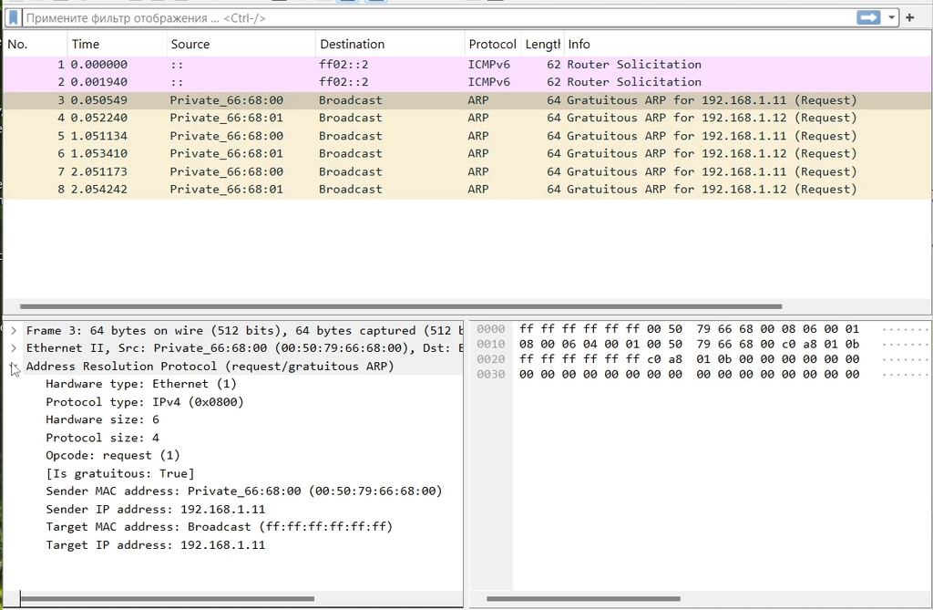

Захват ARP-пакетов

## ICMP

- При выполнении `ping` видны **Echo Request/Reply**.
- Связь функционирует корректно.

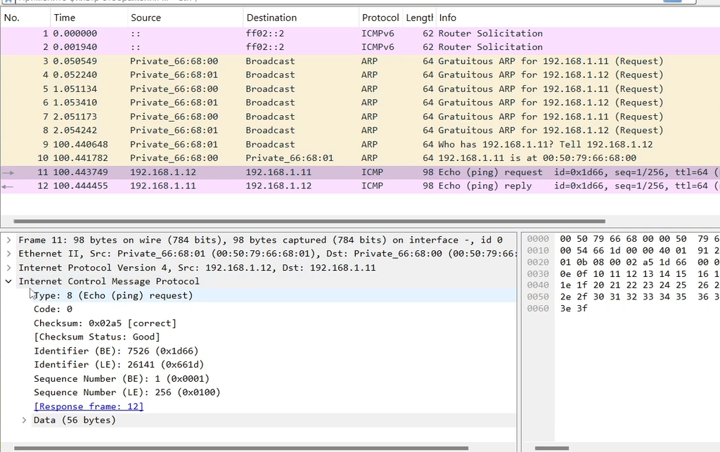

ICMP-запросы в Wireshark

## UDP и TCP

- Захвачены UDP-пакеты (порт назначения 7).
- Зафиксировано трёхстадийное установление TCP-сессии: **SYN**, **SYN-ACK**, **ACK**.
- Завершение — через **FIN-ACK**.

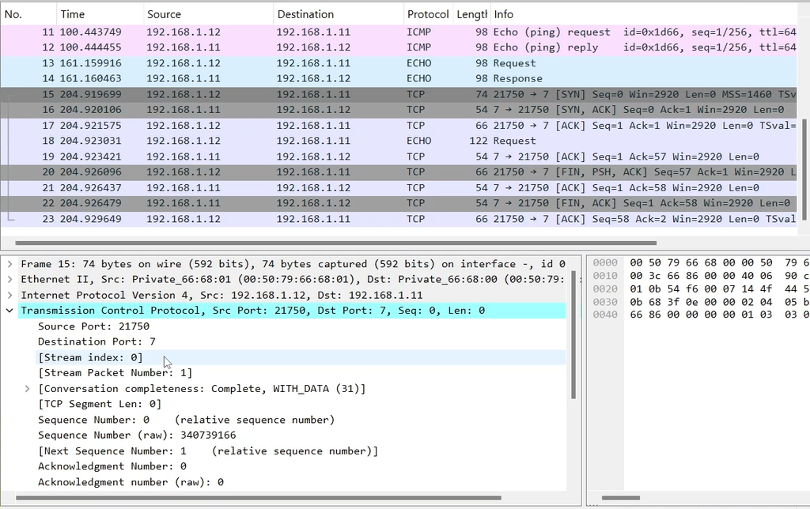

TCP и UDP пакеты

## Настройка сети

- Топология: **FRR**, коммутатор и **VPCS**.
- Маршрутизатор: `192.168.1.1/24`.
- Узел PC1: `192.168.1.10/24`.

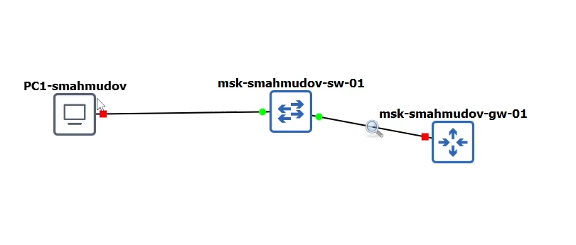

Топология FRR

## Проверка связи и анализ

- Ping между PC1 и маршрутизатором успешен.
- В Wireshark зафиксированы **ARP** и **ICMP Echo** пакеты.

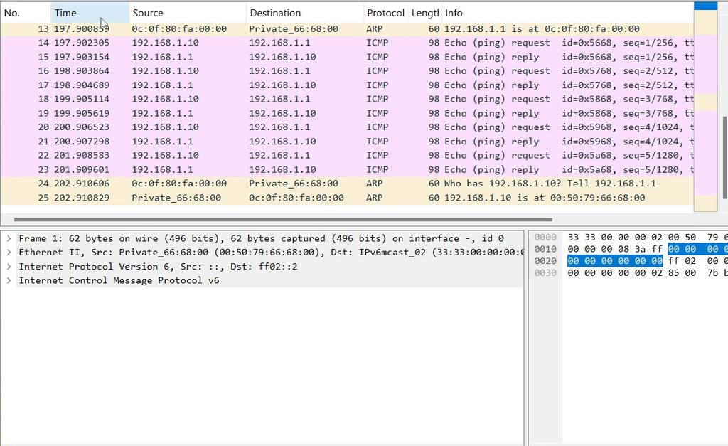

Трафик FRR

## Настройка VyOS

- Установлено имя узла `msk-smahmudov-gw-01`.
- Интерфейс **eth0**: `192.168.1.1/24`.

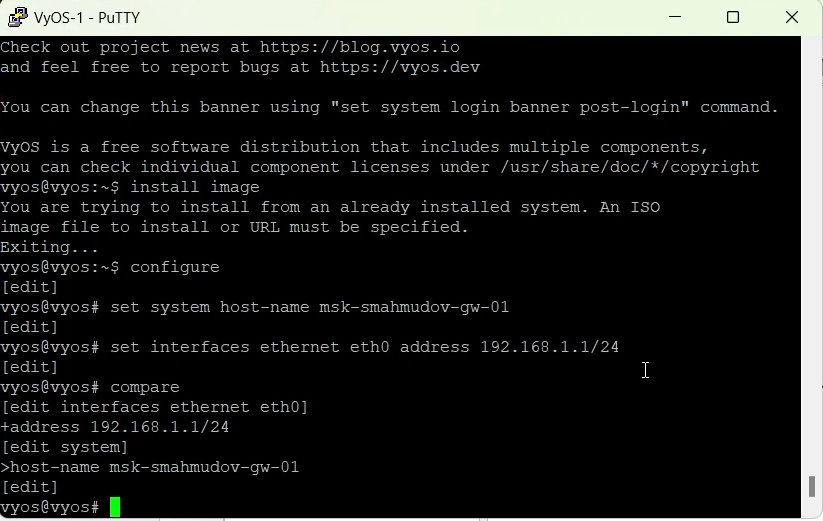

Настройка VyOS

## Проверка соединения

- PC1: `192.168.1.10/24 192.168.1.1`
- Проверка `ping 192.168.1.1` — ответы получены.
- В **Wireshark** зафиксированы **ARP** и **ICMP** пакеты.

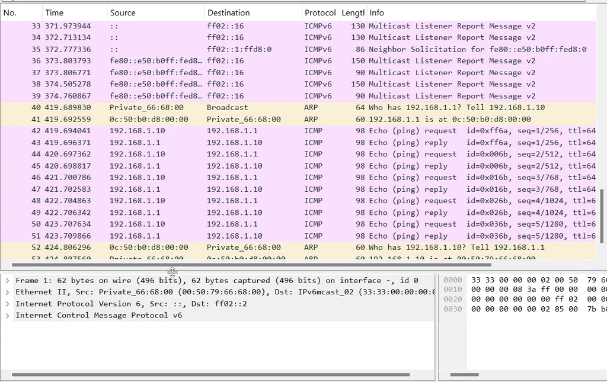

Анализ трафика VyOS

# Вывод

- Смоделированы сети на базе **FRR** и **VyOS**.
- Настроена IP-адресация и проверена связность.
- Проанализированы пакеты **ARP**, **ICMP**, **UDP**, **TCP** в **Wireshark**.
- Подтверждена корректная работа сетевых протоколов и взаимодействие устройств в **GNS3**.